# Matplotlib

There are 8 basic functions as described at http://mathonweb.com/help_ebook/html/functions_4.htm

Create a figure and do the following:

1. use the `seaborn` style sheet
2. create 4 subplots (2x2 2 rows with two subplots each row) with figure size (15, 15)
3. plot the following 3 types of functions: Linear function, Power function, Quadratic function (you can create the specific function yourself) and
- all functions can share the values of x, which should be 50 evenly spaced number between -10 and 10 (hint: use `np.linspace()`)
- add the function type as the title of the subplot
- the quadratic function has to be in the subplot in the first row and second column (you leave one subplot empty and arrange the other two anyway you want
- the functions must have different line style, marker style, and color
- change the x label to x and y label to y
- add legends for each subplot to show the functions

A sample output is as follows:

[figure not shown]

```python
# import matplotlib and finish the figure
import matplotlib.pyplot as plt
```

```python
plt.style.use('seaborn')
```

```python
x = np.linspace(-10,10,50)
y1 = 2*x
y2 = x**2 + 2*x + 1
y3 = x**3
```

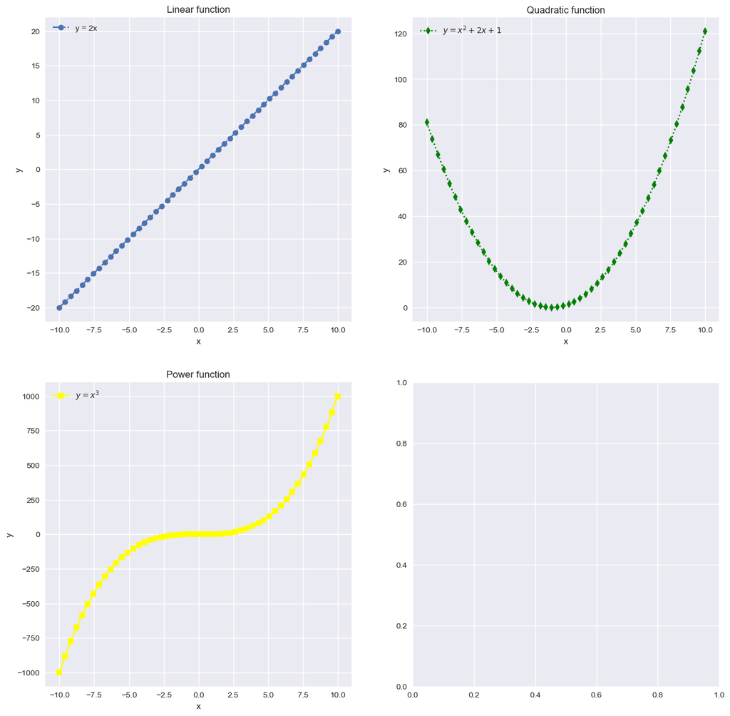

```python
fig, ax = plt.subplots(2,2, figsize=(15,15))

#subplot [0,0]
ax[0,0].plot(x,y1,
    label = 'y = 2x',
    marker = 'o',
    linestyle = 'dashdot'
)
ax[0,0].set_xlabel('x')
ax[0,0].set_ylabel('y')
ax[0,0].legend()
ax[0,0].set_title('Linear function')

#subplot [0,1]
ax[0,1].plot(x,y2,
    label = '$y = x^2 + 2x + 1$',
    marker = 'd',
    color = 'green',
    linestyle='dotted'
)
ax[0,1].set_xlabel('x')
ax[0,1].set_ylabel('y')
ax[0,1].legend()
ax[0,1].set_title('Quadratic function')

# subplot [1,0]
ax[1,0].plot(x,y3,
    label = '$y = x^3$',
    marker = 's',
    color = 'yellow',
    linestyle='solid'
)
ax[1,0].set_xlabel('x')
ax[1,0].set_ylabel('y')
ax[1,0].legend()
ax[1,0].set_title('Power function')
```